# Week 4 In-Class Lab

Tiffany Tang

September 20, 2019

# 1 Goals

In this in-class lab, we will revisit PCA.

# 2 PCA

For our exploration of PCA, we will be looking at gene expression data, obtained from [The Cancer Genome Atlas](https://www.cancer.gov/about-nci/organization/ccg/research/structural-genomics/tcga), for various patients with breast cancer (BRCA). The genomic basis of breast cancer has been extensively studied in the scientific literature, and in particular, scientists have classified breast cancer occurrences into four different subtypes - each with its own defining characteristics and clinical implications (The Cancer Genome Atlas Research Network 2012).

```
## 'data.frame':    241 obs. of  17814 variables:
##  $ ELMO2          : num  0.1814 0.4615 0.877 1.4123 -0.0759 ...
##  $ CREB3L1        : num  0.891 2.259 0.438 -0.637 -0.708 ...
##  $ RPS11          : num  0.716 0.417 0.115 0.493 -0.169 ...
##  $ PNMA1          : num  0.1318 0.325 0.7578 0.9433 -0.0643 ...
##  $ MMP2           : num  0.9578 2.2855 -0.0893 -1.2332 -1.3965 ...
##  $ C10orf90       : num  -0.59 -1.73 -1.78 -2.75 -2.27 ...
##  $ ZHX3           : num  -0.0437 0.4205 0.251 -1.3315 -0.9075 ...
##  $ ERCC5          : num  -0.2385 0.00725 0.03525 0.791 -0.1365 ...
##  $ GPR98          : num  -0.1522 -0.696 -0.6406 0.0145 -0.7439 ...
##  $ RXFP3          : num  0.443 0.296 0.689 -0.06 0.831 ...
##  $ APBB2          : num  1.525 2.127 2.107 0.956 -0.348 ...
##  $ PRO0478        : num  -1.2 -1.42 -1.21 -1.31 -1.31 ...
##  $ KLHL13         : num  0.4612 -0.0005 -1.7125 -0.7518 -2.5315 ...
##  $ PRSSL1         : num  -0.771 -0.685 -0.189 -1.367 -0.849 ...
```

[output cut: 86 more lines]

```
## 'data.frame':    241 obs. of  2 variables:
##  $ BRCA_Subtype_PAM50: Factor w/ 4 levels "Basal","Her2",..: 3 3 3 1 1 1 3 1 4 1 ...
##  $ vital_status      : Factor w/ 2 levels "Alive","Dead": 1 1 1 2 1 1 1 2 1 1 ...
```

```
## List of 5
##  $ sdev    : num [1:241] 142 36.7 25.2 21.4 18.7 ...
##  $ rotation: num [1:17814, 1:241] -0.002301 -0.006123 -0.00279 -0.000482 -0.002334 ...
##   ..- attr(*, "dimnames")=List of 2
##   .. ..$ : chr [1:17814] "ELMO2" "CREB3L1" "RPS11" "PNMA1" ...
##   .. ..$ : chr [1:241] "PC1" "PC2" "PC3" "PC4" ...
##  $ center  : logi FALSE
##  $ scale   : logi FALSE
##  $ x       : num [1:241, 1:241] -154.8 -151.5 -142.7 -99.3 -113.3 ...
##   ..- attr(*, "dimnames")=List of 2
##   .. ..$ : chr [1:241] "TCGA-A1-A0SE" "TCGA-A1-A0SH" "TCGA-A1-A0SJ" "TCGA-A1-A0SK" ...
##   .. ..$ : chr [1:241] "PC1" "PC2" "PC3" "PC4" ...
##  - attr(*, "class")= chr "prcomp"
```

```
## Importance of components:
##                             PC1     PC2      PC3      PC4      PC5
## Standard deviation     142.0187 36.7321 25.22003 21.35938 18.66890
## Proportion of Variance   0.6622  0.0443  0.02088  0.01498  0.01144
## Cumulative Proportion    0.6622  0.7065  0.72734  0.74232  0.75376
##                             PC6     PC7      PC8     PC9    PC10     PC11
## Standard deviation     16.30958 14.8081 14.10133 13.7428 12.7031 11.58498
## Proportion of Variance  0.00873  0.0072  0.00653  0.0062  0.0053  0.00441
## Cumulative Proportion   0.76250  0.7697  0.77622  0.7824  0.7877  0.79213
##                            PC12     PC13     PC14     PC15     PC16
## Standard deviation     11.38964 11.30329 10.92030 10.58951 10.05632
## Proportion of Variance  0.00426  0.00419  0.00392  0.00368  0.00332
## Cumulative Proportion   0.79639  0.80058  0.80450  0.80818  0.81150
##                           PC17    PC18    PC19    PC20    PC21    PC22
## Standard deviation     10.0257 9.73459 9.60620 9.50617 9.34492 9.00312
## Proportion of Variance  0.0033 0.00311 0.00303 0.00297 0.00287 0.00266
## Cumulative Proportion   0.8148 0.81791 0.82094 0.82391 0.82677 0.82944
##                           PC23    PC24    PC25   PC26    PC27    PC28
## Standard deviation     8.84223 8.67627 8.63095 8.5480 8.47325 8.28503
## Proportion of Variance 0.00257 0.00247 0.00245 0.0024 0.00236 0.00225
## Cumulative Proportion  0.83200 0.83447 0.83692 0.8393 0.84167 0.84393
##                           PC29    PC30    PC31    PC32    PC33   PC34
## Standard deviation     8.25980 8.12766 8.03929 7.92246 7.73214 7.6151
## Proportion of Variance 0.00224 0.00217 0.00212 0.00206 0.00196 0.0019
## Cumulative Proportion  0.84617 0.84834 0.85046 0.85252 0.85448 0.8564
##                          PC35    PC36    PC37    PC38   PC39   PC40
## Standard deviation     7.5989 7.51168 7.36157 7.29664 7.2018 7.1871
## Proportion of Variance 0.0019 0.00185 0.00178 0.00175 0.0017 0.0017
## Cumulative Proportion  0.8583 0.86013 0.86191 0.86366 0.8654 0.8671
##                           PC41    PC42    PC43    PC44    PC45    PC46
## Standard deviation     7.14504 7.08077 7.01543 6.99347 6.89452 6.81888
## Proportion of Variance 0.00168 0.00165 0.00162 0.00161 0.00156 0.00153
## Cumulative Proportion  0.86874 0.87038 0.87200 0.87360 0.87516 0.87669
##                          PC47    PC48    PC49    PC50    PC51    PC52
## Standard deviation     6.7592 6.69339 6.67396 6.60828 6.56427 6.48994
## Proportion of Variance 0.0015 0.00147 0.00146 0.00143 0.00141 0.00138
## Cumulative Proportion  0.8782 0.87966 0.88112 0.88256 0.88397 0.88535
##                           PC53    PC54    PC55    PC56    PC57    PC58
## Standard deviation     6.48095 6.39174 6.32429 6.26449 6.23568 6.20517
## Proportion of Variance 0.00138 0.00134 0.00131 0.00129 0.00128 0.00126
```

[output cut: 110 more lines]

```
## Standard deviation     2.92709 2.91566 2.89299 2.88331 2.86008 2.83322
## Proportion of Variance 0.00028 0.00028 0.00027 0.00027 0.00027 0.00026
## Cumulative Proportion  0.99545 0.99573 0.99600 0.99627 0.99654 0.99681
##                          PC228   PC229   PC230   PC231   PC232   PC233
## Standard deviation     2.79930 2.78148 2.76153 2.75670 2.70182 2.68928
## Proportion of Variance 0.00026 0.00025 0.00025 0.00025 0.00024 0.00024
## Cumulative Proportion  0.99706 0.99732 0.99757 0.99782 0.99806 0.99829
##                          PC234   PC235   PC236   PC237   PC238   PC239
## Standard deviation     2.66761 2.62299 2.59736 2.56406 2.53940 2.51807
## Proportion of Variance 0.00023 0.00023 0.00022 0.00022 0.00021 0.00021
## Cumulative Proportion  0.99853 0.99875 0.99898 0.99919 0.99940 0.99961
##                         PC240   PC241
## Standard deviation     2.4649 2.40143
## Proportion of Variance 0.0002 0.00019
## Cumulative Proportion  0.9998 1.00000
```

```
##     Gene         PC1
## 1 IGFBP1  0.05623215
## 2   ASPN -0.05048191
## 3 FCGR3A -0.04742717
## 4   RGS1 -0.04712700
## 5  CD163 -0.04626706
## 6  FABP1  0.04573947
```

1. Create a plot with the cumulative proportion of variance explained on the y-axis and the number of PCs on the x-axis. How many PCs do you need to retain $75\%$ of the variation in the data?

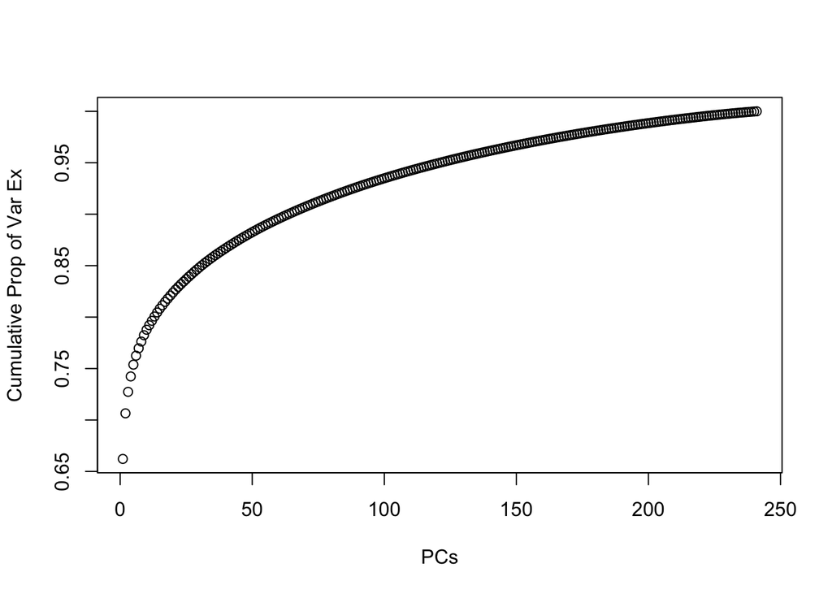

```
## [1] 5
```

But rather than using `prcomp()`, we can also code up PCA directly by computing the SVD using `svd()`.

Given that there is already a built-in R function, `prcomp()`, for performing PCA, there does not seem to be any advantage to using `svd()` over `prcomp()`. However, there is a huge advantage of knowing the relationship between the SVD and PCA because in practice, you typically only need to compute the first few PCs, not all PCs. As a result, you can use really fast algorithms to compute the first few PCs, or equivalently the first few singular vectors, and improve upon the computational complexity of `prcomp()`. This is particularly useful when you have incredibly large datasets. One function for computing the top singular vectors of a matrix is `irlba()` from the `irlba` package.

3. Use the function `irlba()` to compute the first 5 PCs, and compare how long it takes with `prcomp()` and `svd()`.

```
##    user  system elapsed
##   0.352   0.055   0.428
```

```
##    user  system elapsed
##   5.966   0.109   6.253
```

```
##    user  system elapsed
##   4.790   0.097   5.201
```

4. Using the output of `irlba()`, compute the proportion of variance explained for the top 5 PCs without having to compute the full SVD. (Hint: $\text{tr}(\mathbf{X}^{\top} \mathbf{X}) = || \mathbf{X} ||_F^2 = \sum_{i, j} X_{ij}^2$) Compare your result with the results from `prcomp()`.

```
## [1] 0.66216605 0.04429641 0.02088176 0.01497798 0.01144230
```

```
## [1] 0.66216605 0.04429641 0.02088176 0.01497798 0.01144230
```

5. Use `GGally::ggpairs()` to create a matrix of pair plots using the first 5 PCs, and color each point by the cancer subtype. If you’re feeling ambitious, display the proportion of variance explained by each PC in the plot labels using the `columnLabels` argument.

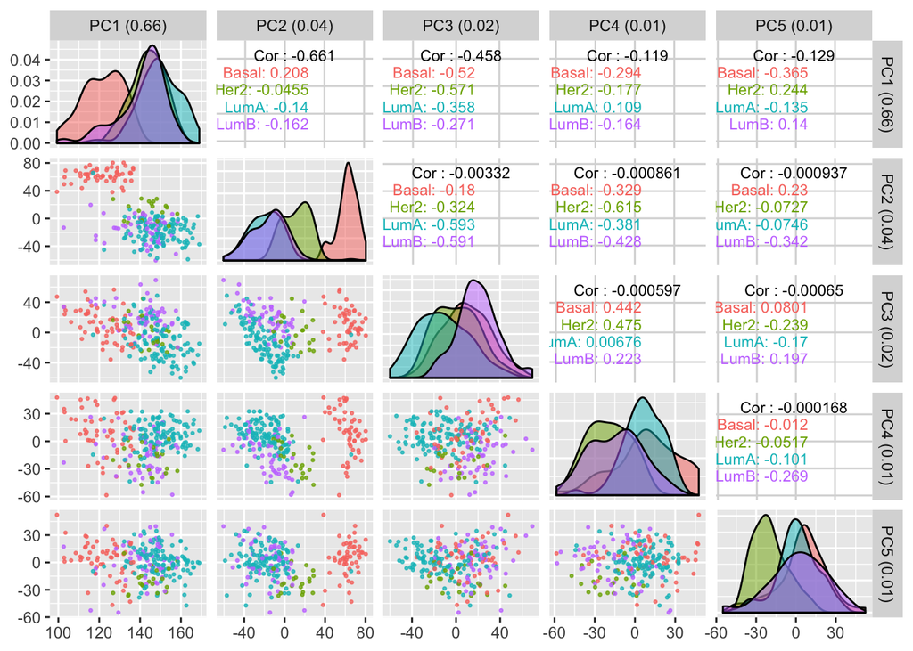

# Bibliography

The Cancer Genome Atlas Research Network. 2012. “Comprehensive Molecular Portraits of Human Breast Tumours.” *Nature* 490 (7418). Nature Publishing Group: 61.